# Brachistochrone: The Best Balance Between Time and Distance

The storytelling of competition between Johann and Jakob Bernoulli, and relevant mathematical knowledge

**NoteGroup Information**

**Group:** Infinitely Good  
**Authors:** Munisa Toshova, Peng Ziqi, Wang Siyi, Yang Zongjing

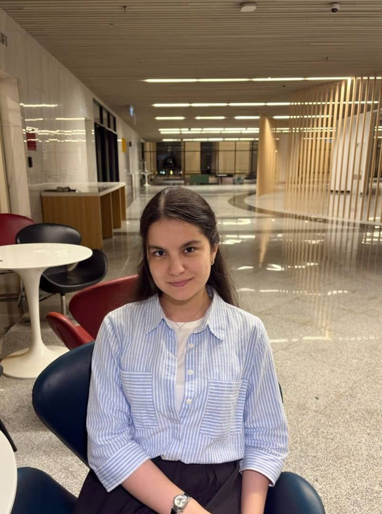

Munisa Toshova

[figure not shown]

Peng Ziqi

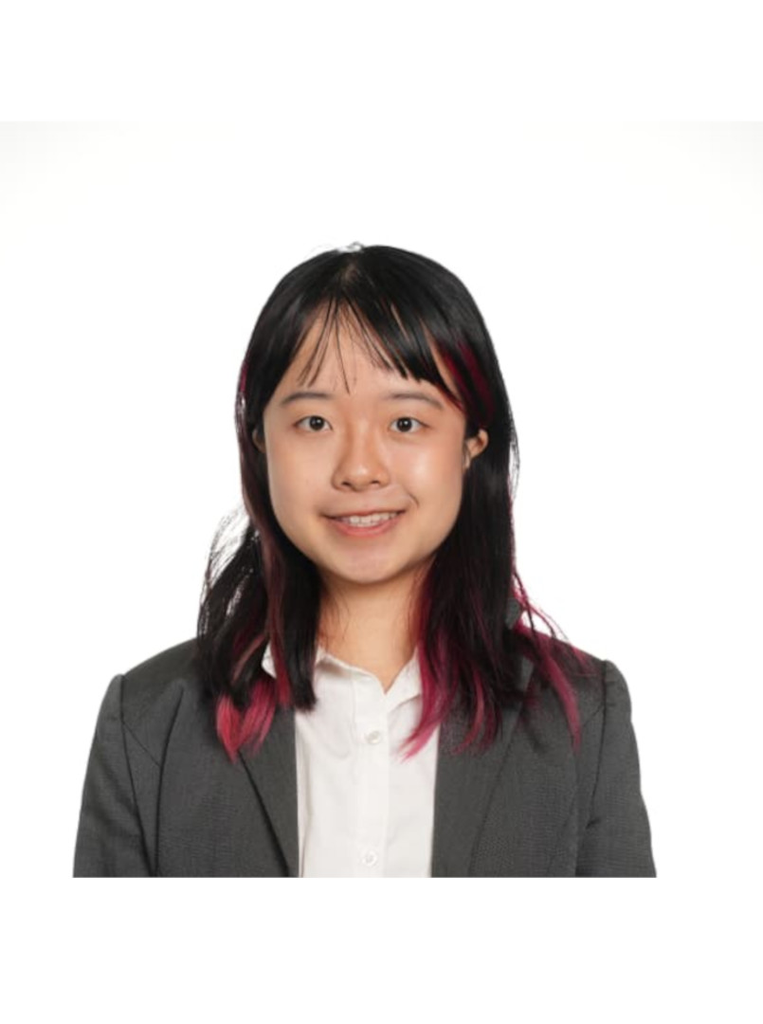

Wang Siyi

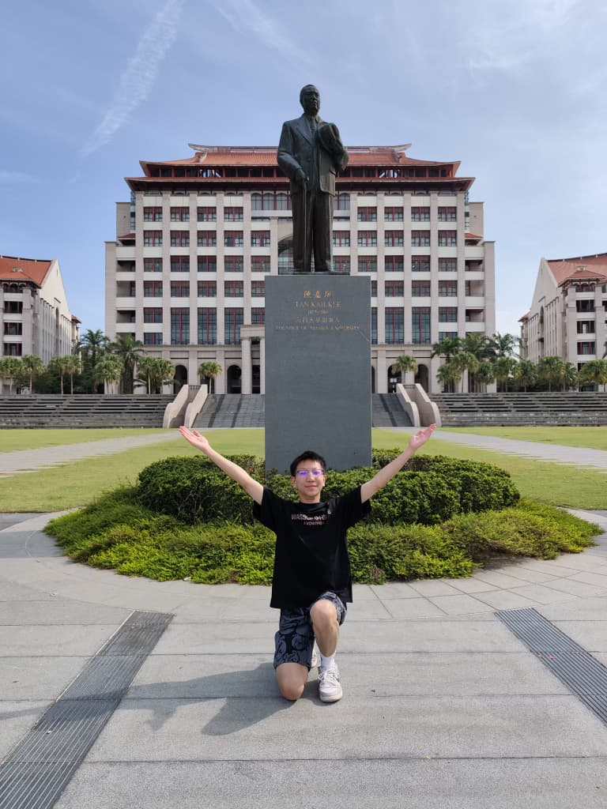

Yang Zongjing

# 1 Introduction

### 1.0.1 A deceptively simple question

Imagine fixing two nails to a wall, one higher than the other. If you stretch a wire between them and let a tiny bead slide down under gravity, which path gets it to the bottom the fastest?

Most people would guess a straight line—after all, it’s the shortest distance between two points, right? But here is the fascinating twist: the shortest path is not always the fastest.

> “If two points are connected by different curves, find the one along which a moving body, falling under its own weight, reaches the lower point in the shortest time.”

> — Johann Bernoulli’s challenge to the mathematicians of Europe, 1696

Named from the Greek words brachistos (shortest) and chronos (time), the Brachistochrone Problem might look like a simple physics puzzle—one you could solve with just a ruler and some intuition. Yet, what seemed like a minor riddle ultimately ignited one of the most profound revolutions in modern mathematics.

We chose this problem because it perfectly illustrates a fascinating truth about math: a single, simple question can completely reshape human thought. In this case, that intellectual seed blossomed into the Calculus of Variations—a powerful field that today shapes everything from spacecraft trajectories and robotic motion to artificial intelligence and economic modeling.

What makes this story even richer is its intensely human element. The puzzle sparked a fierce, bitter rivalry between some of Europe’s greatest minds, most notably the Bernoulli brothers. Driven by a relentless desire to outdo each other, their clash of egos ultimately birthed a mathematical breakthrough that neither could have achieved alone.

As we explored this story, three lessons stood out to us:

| **Competition can inspire discovery.** | Johann and Jakob Bernoulli’s fierce competition pushed both of them further than collaboration alone might have. |  |
| --- | --- | --- |
| **Different approaches, same answer.** | Newton, Leibniz, and both Bernoullis each solved it differently — proving maths has more than one road to the same answer. |  |
| **One problem, a new field** | The brachistochrone didn’t just get solved — it created a method. That method is still used in physics, engineering, and AI today. |  |

Turning the pages of this history, you’ll discover that it wasn’t just an academic breakthrough, but also a thrilling contest between geniuses.

The Bernoulli brothers argued, competed, and pushed each other to the very edge of what was mathematically known. So did Newton, Leibniz, and the other great minds who took up the challenge. In doing so, they did not merely answer one question — they invented a new way of thinking.

That is why we find this problem so captivating. It is not just a clever puzzle. It is a reminder that mathematics grows not only through careful reasoning, but through curiosity, discussion, and the willingness to look at a problem from an angle nobody has tried before.

# 2 Background

[figure not shown]

Johann Bernoulli

[figure not shown]

Jacob Bernoulli

The story of Johann Bernoulli and Jakob Bernoulli is one of the most fascinating stories in mathematics.  
They were brothers from Switzerland in the late 17th century who helped develop calculus after the work of Newton and Leibniz. Although they were both brilliant mathematicians, they became fierce rivals. Their competition led to important discoveries that shaped modern calculus.

[figure not shown]

all of them

## 2.1 The Beginning

Jakob Bernoulli (1654–1705), the older brother, was the first in the family to study mathematics.

Johann Bernoulli (1667–1748), his younger brother, initially studied medicine. However, after seeing Jakob’s success and becoming interested in mathematics, Johann began learning calculus from his brother.

At first, Jakob acted as Johann’s teacher. Johann learned quickly and soon became as skilled as his older brother. What started as a close partnership gradually turned into a rivalry.

## 2.2 The Birth of a Competition

As both brothers became experts in calculus, they competed to solve increasingly difficult mathematical problems. Each wanted to be recognized as the better mathematician. Their rivalry became so intense that they often criticized each other’s work publicly. Despite their disagreements, this competition motivated them to push the boundaries of mathematics.

## 2.3 The Brachistochrone Problem

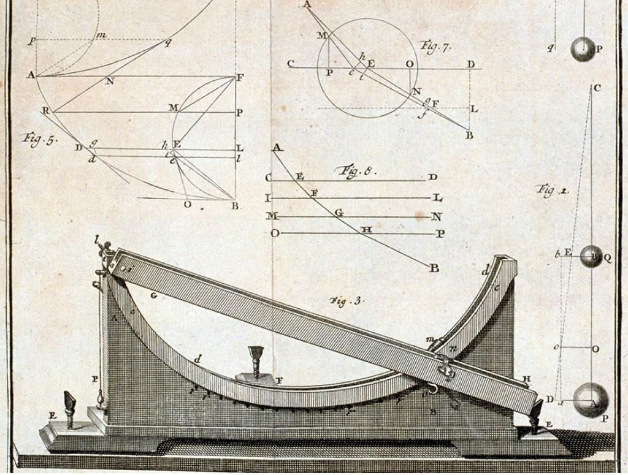

historical

In 1696, Johann Bernoulli proposed a famous challenge to mathematicians across Europe:

> “What is the shape of a curve along which a ball will travel from one point to another in the shortest time under gravity?”

Many mathematicians attempted to solve the problem, including Jakob Bernoulli, Newton, and Leibniz.

Surprisingly, the answer was not a straight line. The fastest path was a curve called a cycloid. This challenge became known as the Brachistochrone Problem (from Greek words meaning “shortest time”).

## 2.4 Why It Was Important

The Brachistochrone Problem could not be solved using ordinary geometry. It required a new mathematical approach. The methods developed to solve it eventually led to the Calculus of Variations, a branch of calculus used to find optimal solutions. Today, these ideas are used in:

- Engineering design
- Spacecraft trajectories
- Robotics
- Economics
- Artificial intelligence

## 2.5 Their Legacy

The Bernoulli brothers made enormous contributions to mathematics. Jakob contributed to:

- Probability theory
- Infinite series
- Early calculus

Johann contributed to: - Differential equations - Calculus education - Calculus of variations

Their work inspired later mathematicians such as Leonhard Euler, who became one of the greatest mathematicians in history.

# 3 Mathematical Discussion

## 3.1 Energy Conservation and Velocity Function

```javascript
raceFigure = {
  const g = 9.81;
  const X = 5;
  const H = 3;
  const samples = 1400;

  // Solve for the cycloid parameter that passes through (X, H).
  const ratio = X / H;
  let lo = 0.05, hi = 2 * Math.PI - 0.05;
  for (let k = 0; k < 80; ++k) {
    const m = (lo + hi) / 2;
    const value = (m - Math.sin(m)) / (1 - Math.cos(m));
    if (value < ratio) lo = m; else hi = m;
  }
  const thetaEnd = (lo + hi) / 2;
  const cycloidRadius = H / (1 - Math.cos(thetaEnd));

  // A circular arc with a vertical tangent at the release point.
  const circleAngle = 2 * Math.atan(X / H);
  const circleRadius = H / Math.sin(circleAngle);

  const definitions = [
    {
      name: "Cycloid",
      color: "#6f42c1",
      point: s => {
        const t = thetaEnd * s;
        return {
          x: cycloidRadius * (t - Math.sin(t)),
          y: cycloidRadius * (1 - Math.cos(t))
        };
      }
    },
    {
      name: "Straight line",
      color: "#dc3545",
      point: s => ({x: X * s, y: H * s})
    },
    {
      name: "Parabola",
      color: "#198754",
      point: s => ({x: X * s * s, y: H * s})
    },
    {
      name: "Circular arc",
      color: "#0d6efd",
      point: s => {
        const t = circleAngle * s;
        return {
          x: circleRadius * (1 - Math.cos(t)),
          y: circleRadius * Math.sin(t)
        };
      }
    }
  ];

  // Unlabelled comparison tracks: subtle variations between the four main paths.
  const auxiliaryDefinitions = [
    ...[0.58, 0.72, 1.28, 1.52].map(power => ({
      color: "#ffffff",
      point: s => ({x: X * s, y: H * Math.pow(s, power)})
    })),
    ...[-0.20, -0.10, 0.10, 0.20].map(bend => ({
      color: "#ffffff",
      point: s => ({x: X * s, y: H * (s + bend * Math.sin(Math.PI * s))})
    }))
  ];

  function preparePath(definition) {
    const points = Array.from({length: samples + 1}, (_, i) =>
      definition.point(i / samples)
    );
    const times = new Float64Array(samples + 1);

    for (let i = 1; i <= samples; ++i) {
      const p0 = points[i - 1];
      const p1 = points[i];
      const ds = Math.hypot(p1.x - p0.x, p1.y - p0.y);
      const v0 = Math.sqrt(2 * g * Math.max(0, p0.y));
      const v1 = Math.sqrt(2 * g * Math.max(0, p1.y));
      // 2 ds / (v0 + v1) remains finite at the release point.
      times[i] = times[i - 1] + (2 * ds) / Math.max(v0 + v1, 1e-12);
    }
    return {...definition, points, times, finish: times[samples]};
  }

  const paths = definitions.map(preparePath);
  const auxiliaryPaths = auxiliaryDefinitions.map(preparePath);
  const allPaths = [...paths, ...auxiliaryPaths];
  const raceEnd = Math.max(...allPaths.map(d => d.finish));

  function positionAt(path, time) {
    if (time >= path.finish) return path.points[path.points.length - 1];
    let left = 0, right = path.times.length - 1;
    while (right - left > 1) {
      const mid = (left + right) >> 1;
      if (path.times[mid] <= time) left = mid; else right = mid;
    }
    const span = path.times[right] - path.times[left];
    const f = span > 0 ? (time - path.times[left]) / span : 0;
    const a = path.points[left], b = path.points[right];
    return {x: a.x + f * (b.x - a.x), y: a.y + f * (b.y - a.y)};
  }

  const wrapper = html`<div style="max-width:960px;margin:1rem auto;font-family:system-ui,sans-serif">
    <div style="display:flex;gap:.65rem;align-items:center;flex-wrap:wrap;margin-bottom:.8rem">
      <button style="min-width:7.5rem;padding:.45rem .8rem;border:0;border-radius:.35rem;background:#6f42c1;color:white;font-weight:650;cursor:pointer">▶️ Play</button>
      <button class="reset" style="padding:.45rem .8rem;border:1px solid #888;border-radius:.35rem;background:transparent;cursor:pointer">↺ Reset</button>
      <input type="range" min="0" max="${raceEnd}" value="0" step="0.001" style="flex:1;min-width:230px" aria-label="Race time">
      <output style="min-width:6.8rem;font-variant-numeric:tabular-nums;font-weight:650">t = 0.000 s</output>
    </div>
    <svg viewBox="0 0 760 470" role="img" aria-label="Four beads racing along different tracks" style="width:100%;height:auto;background:linear-gradient(#000000,#000000);border-radius:.6rem"></svg>
    <div class="results" style="display:grid;grid-template-columns:repeat(auto-fit,minmax(150px,1fr));gap:.5rem;margin-top:.7rem"></div>
    <p style="font-size:.88rem;color:#666;margin-top:.55rem">The timer uses numerical integration of <span style="font-family:serif">dt = ds / √(2gy)</span>. A bead remains at the endpoint after it finishes.</p>
  </div>`;

  const svg = wrapper.querySelector("svg");
  const playButton = wrapper.querySelector("button");
  const resetButton = wrapper.querySelector(".reset");
  const slider = wrapper.querySelector("input");
  const output = wrapper.querySelector("output");
  const results = wrapper.querySelector(".results");
  const ns = "http://www.w3.org/2000/svg";
  const margin = {left: 65, top: 45};
  const sx = x => margin.left + x * 126;
  const sy = y => margin.top + y * 118;

  const title = document.createElementNS(ns, "text");
  title.setAttribute("x", "380");
  title.setAttribute("y", "27");
  title.setAttribute("text-anchor", "middle");
  title.setAttribute("font-size", "17");
  title.setAttribute("font-weight", "700");
  title.textContent = "Beads released simultaneously — vertical direction is downward";
  svg.append(title);

  const trackGroup = document.createElementNS(ns, "g");
  const beadGroup = document.createElementNS(ns, "g");
  svg.append(trackGroup, beadGroup);

  const beads = [];
  const auxiliaryBeads = [];
  const cards = [];

  // Draw auxiliary tracks first so the four named tracks stay visually dominant.
  for (const path of auxiliaryPaths) {
    const track = document.createElementNS(ns, "path");
    track.setAttribute("d", path.points.map((p, i) =>
      `${i ? "L" : "M"}${sx(p.x).toFixed(2)},${sy(p.y).toFixed(2)}`
    ).join(" "));
    track.setAttribute("fill", "none");
    track.setAttribute("stroke", path.color);
    track.setAttribute("stroke-width", "1.6");
    track.setAttribute("opacity", ".42");
    trackGroup.append(track);

    const bead = document.createElementNS(ns, "circle");
    bead.setAttribute("r", "5.2");
    bead.setAttribute("fill", "#adb5bd");
    bead.setAttribute("stroke", "#f8f9fa");
    bead.setAttribute("stroke-width", "1.3");
    bead.setAttribute("opacity", ".82");
    beadGroup.append(bead);
    auxiliaryBeads.push(bead);
  }

  for (const path of paths) {
    const track = document.createElementNS(ns, "path");
    track.setAttribute("d", path.points.map((p, i) =>
      `${i ? "L" : "M"}${sx(p.x).toFixed(2)},${sy(p.y).toFixed(2)}`
    ).join(" "));
    track.setAttribute("fill", "none");
    track.setAttribute("stroke", path.color);
    track.setAttribute("stroke-width", path.name === "Cycloid" ? "4" : "3");
    track.setAttribute("opacity", ".82");
    trackGroup.append(track);

    const bead = document.createElementNS(ns, "circle");
    bead.setAttribute("r", "9");
    bead.setAttribute("fill", path.color);
    bead.setAttribute("stroke", "white");
    bead.setAttribute("stroke-width", "2.5");
    beadGroup.append(bead);
    beads.push(bead);

    const card = document.createElement("div");
    card.style.cssText = `border-left:5px solid ${path.color};padding:.45rem .6rem;background:rgba(128,128,128,.08);border-radius:.25rem`;
    results.append(card);
    cards.push(card);
  }

  for (const [label, p] of [["START", {x:0,y:0}], ["FINISH", {x:X,y:H}]]) {
    const marker = document.createElementNS(ns, "circle");
    marker.setAttribute("cx", sx(p.x)); marker.setAttribute("cy", sy(p.y));
    marker.setAttribute("r", "5"); marker.setAttribute("fill", "#222");
    trackGroup.append(marker);
    const text = document.createElementNS(ns, "text");
    text.setAttribute("x", sx(p.x) + (label === "START" ? 12 : -12));
    text.setAttribute("y", sy(p.y) + (label === "START" ? -10 : 24));
    text.setAttribute("text-anchor", label === "START" ? "start" : "end");
    text.setAttribute("font-size", "13"); text.setAttribute("font-weight", "700");
    text.textContent = label; trackGroup.append(text);
  }

  let playing = false;
  let currentTime = 0;
  let previousFrame = null;
  let frameRequest = null;

  function draw(time) {
    currentTime = Math.max(0, Math.min(raceEnd, time));
    slider.value = currentTime;
    output.value = `t = ${currentTime.toFixed(3)} s`;
    paths.forEach((path, i) => {
      const p = positionAt(path, currentTime);
      beads[i].setAttribute("cx", sx(p.x));
      beads[i].setAttribute("cy", sy(p.y));
      const finished = currentTime >= path.finish;
      cards[i].innerHTML = `<strong style="color:${path.color}">${path.name}</strong><br>` +
        `finish: ${path.finish.toFixed(3)} s<br>` +
        `<span style="font-size:.86rem">${finished ? "✓ finished" : `height descended: ${p.y.toFixed(2)} m`}</span>`;
    });
    auxiliaryPaths.forEach((path, i) => {
      const p = positionAt(path, currentTime);
      auxiliaryBeads[i].setAttribute("cx", sx(p.x));
      auxiliaryBeads[i].setAttribute("cy", sy(p.y));
    });
  }

  function animate(timestamp) {
    if (!playing) return;
    if (previousFrame == null) previousFrame = timestamp;
    const elapsed = (timestamp - previousFrame) / 1000;
    previousFrame = timestamp;
    draw(currentTime + elapsed);
    if (currentTime >= raceEnd) {
      playing = false;
      playButton.textContent = "Replay";
      previousFrame = null;
      return;
    }
    frameRequest = requestAnimationFrame(animate);
  }

  playButton.onclick = () => {
    if (currentTime >= raceEnd) draw(0);
    playing = !playing;
    playButton.textContent = playing ? "Pause" : "Play";
    previousFrame = null;
    if (playing) frameRequest = requestAnimationFrame(animate);
  };

  resetButton.onclick = () => {
    playing = false;
    if (frameRequest) cancelAnimationFrame(frameRequest);
    previousFrame = null;
    playButton.textContent = "Play";
    draw(0);
  };

  slider.oninput = () => {
    playing = false;
    if (frameRequest) cancelAnimationFrame(frameRequest);
    previousFrame = null;
    playButton.textContent = "Play";
    draw(+slider.value);
  };

  invalidation.then(() => {
    playing = false;
    if (frameRequest) cancelAnimationFrame(frameRequest);
  });

  draw(0);
  return wrapper;
}

raceFigure
```

[interactive chart not shown]

To determine the curve of quickest descent, we first investigate how the velocity of a particle changes as it moves under the influence of gravity.

Consider a particle that starts from rest and slides along a smooth curve without friction. Since no non-conservative forces are present, the total mechanical energy remains constant throughout the motion. Let $y$ denote the vertical distance descended from the starting point. The loss of gravitational potential energy is converted entirely into kinetic energy, giving

$$mgy = \frac{1}{2}mv^2$$

After cancelling the mass $m$, we obtain

$$v = \sqrt{2gy}$$

where $g$ is the acceleration due to gravity and $v$ is the speed of the particle.

This equation shows that the speed of the particle depends only on its vertical position. As the particle descends, its speed increases. Therefore, the total travel time depends not only on the length of the path but also on how quickly the particle gains speed along that path.

Consequently, the shortest path is not necessarily the fastest path.

## 3.2 Construction of the Time Functional

The objective of the brachistochrone problem is to determine the curve that minimizes the total travel time.

Consider a small segment of the curve with arc length $ds$. The time required to traverse this segment is

$$dt = \frac{ds}{v}$$

Suppose the curve is represented by the function $y = y(x)$. From the arc length formula in Calculus II,

$$ds = \sqrt{1 + \left(\frac{dy}{dx}\right)^2} \, dx = \sqrt{1 + y'^2} \, dx$$

Substituting this expression into the time element yields

$$dt = \frac{\sqrt{1 + y'^2}}{v} \, dx$$

Using the velocity obtained from energy conservation,

$$v = \sqrt{2gy}$$

we obtain

$$dt = \frac{\sqrt{1 + y'^2}}{\sqrt{2gy}} \, dx$$

Integrating along the entire path gives the total travel time

$$T = \int_{x_1}^{x_2} \frac{\sqrt{1 + y'^2}}{\sqrt{2gy}} \, dx$$

This expression represents the time required for the particle to move from the initial point to the final point.

The problem is therefore transformed into finding the function $y(x)$ that minimizes the value of $T$.

## 3.3 From Classical Optimization to the Calculus of Variations

In elementary calculus, optimization problems involve finding the maximum or minimum value of a function.

For example, given

$$f(x) = x^2 - 4x + 3$$

the optimal value can be found by solving

$$f'(x) = 0$$

The brachistochrone problem is fundamentally different.

Instead of selecting a single value of $x$, we must determine an entire function $y(x)$. Every possible curve connecting the two endpoints produces a different value of the travel-time integral

$$T = \int_{x_1}^{x_2} \frac{\sqrt{1 + y'^2}}{\sqrt{2gy}} \, dx$$

The mathematical discipline developed to solve such problems is known as the **calculus of variations**.

Rather than optimizing numbers, the calculus of variations optimizes functions. This idea represented a major breakthrough in mathematics and became the foundation for many later developments in physics and engineering.

**Functional visualization: The effect of perturbation on descent time**

```javascript
viewof perturbation = Inputs.range([-5, 1.7], {value: 0, step: 0.1, label: "Curve disturbance (ε)"})


g = 9.81;
x_end = 5;


simulation = {
  const n = 100;
  let totalTime = 0;
  const points = [];


  const baseForm = x => -Math.pow(x, 1.2);

  const eta = x => Math.sin((Math.PI * x) / x_end);

  for (let i = 0; i <= n; i++) {
    const x = (i / n) * x_end;

    const y = baseForm(x) + perturbation * eta(x);
    points.push({ x: x, y: y });
  }



  for (let i = 0; i < n; i++) {
    const x1 = points[i].x;
    const y1 = points[i].y;
    const x2 = points[i+1].x;
    const y2 = points[i+1].y;

    const dx = x2 - x1;
    const dy = y2 - y1;
    const ds = Math.sqrt(dx * dx + dy * dy);


    const v1 = Math.sqrt(Math.max(0, -2 * g * y1));
    const v2 = Math.sqrt(Math.max(0, -2 * g * y2));

    const vAvg = (v1 + v2) / 2;

    if (vAvg > 0.0001) {
      totalTime += ds / vAvg;
    } else {

      totalTime = Infinity;
      break;
    }
  }

  return { points: points, time: totalTime };
}


md`### ⏱️ Total descent time of the current curve: **${simulation.time.toFixed(4)}** s`
```

[interactive chart not shown]

```javascript
Plot.plot({
  marks: [

    Plot.lineY(simulation.points, {x: "x", y: "y", stroke: "purple", strokeWidth: 3}),

    Plot.dot([{x:0, y:0}, {x:5, y:simulation.points[simulation.points.length-1].y}], {x:"x", y:"y", fill:"black", r:5})
  ],
  y: {domain: [-8, 1]},
  grid: true
})
```

[interactive chart not shown]

## 3.4 Euler–Lagrange Equation

The central result of the calculus of variations is the Euler–Lagrange equation.

Consider a functional of the form

$$J[y] = \int_{x_1}^{x_2} L(y, y') \, dx$$

where $L$ is called the Lagrangian.

A necessary condition for $J[y]$ to attain an extremum is that the function $y(x)$ satisfies

$$\frac{\partial L}{\partial y} - \frac{d}{dx}\left(\frac{\partial L}{\partial y'}\right) = 0$$

For the brachistochrone problem, the Lagrangian is

$$L(y, y') = \sqrt{\frac{1 + y'^2}{2gy}}$$

Substituting this expression into the Euler–Lagrange equation produces a differential equation describing the curve of minimum travel time.

Although the derivation is beyond the scope of this project, the key idea is that the original optimization problem has been transformed into a differential equation that can be analyzed mathematically.

## 3.5 Application of the Beltrami Identity

The brachistochrone problem possesses a special property because the Lagrangian

$$L(y, y') = \sqrt{\frac{1 + y'^2}{2gy}}$$

does not explicitly contain the independent variable $x$.

In such cases, the Euler–Lagrange equation can be simplified using the Beltrami Identity

$$L - y' \frac{\partial L}{\partial y'} = C$$

where $C$ is a constant.

Applying this identity to the brachistochrone Lagrangian and simplifying yields

$$\frac{1}{\sqrt{2gy(1 + y'^2)}} = C$$

After rearranging and absorbing constants into a new parameter, we obtain

$$y(1 + y'^2) = a$$

where $a$ is a positive constant.

This first-order differential equation is the key mathematical result needed to determine the shape of the brachistochrone curve.

## 3.6 Derivation of the Cycloid

Starting from

$$y(1 + y'^2) = a$$

we obtain

$$1 + y'^2 = \frac{a}{y}$$

which implies

$$y'^2 = \frac{a - y}{y}$$

Taking the positive branch,

$$\frac{dy}{dx} = \sqrt{\frac{a - y}{y}}$$

Rewriting gives

$$dx = \sqrt{\frac{y}{a - y}} \, dy$$

The square root suggests a trigonometric substitution. Let

$$y = a\sin^2\!\left(\frac{\theta}{2}\right)$$

Using the identity

$$\sin^2\!\left(\frac{\theta}{2}\right) = \frac{1 - \cos\theta}{2}$$

we obtain

$$y = \frac{a}{2}(1 - \cos\theta)$$

Differentiating with respect to $\theta$,

$$dy = \frac{a}{2}\sin\theta \, d\theta$$

Substituting into the expression for $dx$,

$$dx = \sqrt{\frac{\dfrac{a}{2}(1 - \cos\theta)}{\dfrac{a}{2}(1 + \cos\theta)}} \cdot \frac{a}{2}\sin\theta \, d\theta$$

Using the half-angle identities,

$$dx = \frac{a}{2}(1 - \cos\theta) \, d\theta$$

Integrating both sides gives

$$x = \frac{a}{2} \int (1 - \cos\theta) \, d\theta$$

Thus,

$$x = \frac{a}{2}(\theta - \sin\theta)$$

If we redefine the constant $\frac{a}{2}$ as $a$, the parametric equations become

$$x = a(\theta - \sin\theta)$$

and

$$y = a(1 - \cos\theta)$$

These equations describe a cycloid.

**Geometric parameter analysis of the brachistochrone (cycloid)**

```javascript
viewof R = Inputs.range([1, 10], {value: 5, step: 0.1, label: "radius of a circle (R)"})
viewof maxTheta = Inputs.range([0.1, 2 * Math.PI], {value: Math.PI, step: 0.05, label: "scrolling angle (θ)"})


cycloidData = {
  const steps = 200;
  return Array.from({length: steps}, (_, i) => {
    const t = (i / (steps - 1)) * maxTheta;
    return {
      x: R * (t - Math.sin(t)),
      y: -R * (1 - Math.cos(t))
    };
  });
}


Plot.plot({
  marks: [
    Plot.lineY(cycloidData, {x: "x", y: "y", stroke: "blue", strokeWidth: 3}),

    Plot.dot([cycloidData[cycloidData.length - 1]], {x: "x", y: "y", fill: "red", r: 6})
  ],
  grid: true,
  aspectRatio: 1
})
```

[interactive chart not shown]

A cycloid is the curve traced by a point on the circumference of a circle as the circle rolls along a straight line.

Therefore, the curve of quickest descent is a cycloid rather than a straight line, parabola, or circular arc.

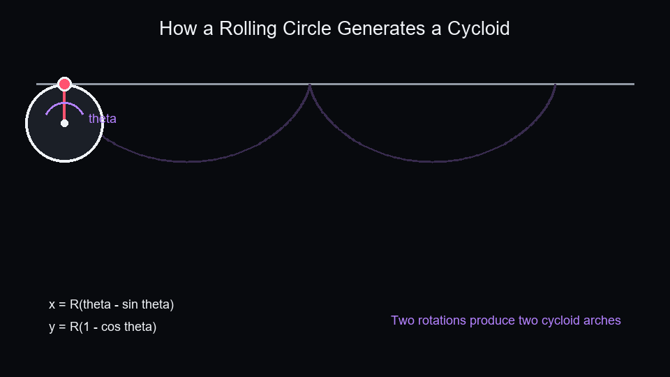

rolling circle

## 3.7 Interpretation and Significance

The solution demonstrates that minimizing distance and minimizing time are fundamentally different objectives.

Although a straight line provides the shortest distance between two points, it does not allow the particle to gain speed quickly enough. The cycloid begins with a steeper descent, enabling the particle to accelerate rapidly before travelling the remaining distance at a much higher speed.

As a result, the total travel time along the cycloid is less than that of any other curve connecting the same endpoints.

The brachistochrone problem occupies an important place in the history of mathematics because it inspired the development of the calculus of variations. The techniques introduced to solve this problem later became fundamental tools in mechanics, optics, control theory, and modern physics.

Therefore, the brachistochrone problem is not only a remarkable application of calculus but also a milestone in the development of mathematical science.

# 4 Conclusion

## 4.1 What a sliding bead taught the world

The answer to Johann Bernoulli’s challenge turned out to be the cycloid — the graceful curve traced by a point on the rim of a rolling wheel. The answer wasn’t a straight line. It wasn’t a parabola.  
It wasn’t any curve most people would expect. It was a cycloid—a curve traced by a point on the edge of a rolling wheel. A curve that nobody expected, and that everyone, once they saw the proof, could not deny.

This result carries a quiet but powerful lesson that extends far beyond physics. When we optimize for the right objective rather than the most obvious one, the answer can look completely different from what intuition suggests. The straight line feels efficient. The cycloid actually is.

## 4.2 Why this still matters today

The techniques invented to solve the brachistochrone became the Calculus of Variations — used today in designing rocket flight paths, training neural networks, modeling financial markets, and understanding how light bends through optical systems. It’s amazing that a question asked over 300 years ago about a tiny bead sliding along a wire still influences rockets, robots, artificial intelligence, and even finance today.

As first-year mathematics students, this project give us a chance to think more deep on mathematics. We realized that maths isn’t just about finding answers—it’s about asking better questions. A single question, if it’s interesting enough, can lead to ideas that change the world.

The Bernoulli brothers disagreed, challenged each other publicly, and drove one another past the boundaries of what was known. In doing so, they handed future generations a powerful set of tools. That is perhaps the most beautiful thing about mathematics: even its rivalries leave the world richer.

The brachistochrone problem began with a simple question about the fastest path between two points. It started with a simple question about a falling bead, but it ended up changing how mathematicians solve optimization problems—and that influence is still with us today. And that, more than any single formula or theorem, is why we chose to tell this story.

> “Sometimes the fastest way forward isn’t the most obvious one. That’s exactly what the Brachistochrone Problem taught mathematicians more than 300 years ago—and it’s a lesson that still inspires us today.”

> The Brachistochrone Problem, 1696 — still teaching us something new.